# DC 3: Plotting Data

Brian Rusk

July 12th & 13th, 2017

## Packages

These packages are used in this lesson:

```r
library(ggplot2)
library(dplyr)
library(ggthemes) # install.packages("ggthemes")
library(hflights) # install.packages("hflights")
```

## Base Graphics

R bills itself as a language and environment for statistical computing *and* graphics, and base R has some pretty decent capabilities. However, the `ggplot2` package is ultimately more versatile and easier to use. If you should end up using `ggplot2` anyway, then we will spend more time on this. There are some very useful base R plots, and I’ll cover those, but we will not spend much time customizing them. (I admit, I have actually forgotten most of what I did at one time know about base R graphics).

As I mentioned, when your data grows very large (think: 30 columns and millions of rows), taking a look at the data is not going to be very informative. This is why we want functions like `mean()` or `summary()`. Sometimes though, a picture is worth 1000 words and a simple plot can help us understand what we are looking at. Most useful among these are histograms, density plots, and scatterplots. For example a histogram or a density plot can tell us if the data is normally distributed, which is an assumption of many statistical tests.

```r
hist(iris$Sepal.Length[iris$Species == "setosa"])
```

[output not shown]

Naturally there are many options for `hist()` but it is most useful for just letting the analyst visualize the data.

```r
hist(iris$Sepal.Length[iris$Species == "setosa"], breaks = 10, col = "blue", xlab = "Sepal Length",
    main = "Histogram for Setosa")
```

[output not shown]

```r
plot(density(iris$Petal.Length[iris$Species == "virginica"]))
```

[output not shown]

As we saw, scatterplots can give us a quick visualization of relationships.

```r
plot(MTcars$disp, MTcars$hp)
```

[output not shown]

We can even produce a scatterplot matrix to look at multiple relationships.

```r
pairs(~Sepal.Length + Sepal.Width + Petal.Length + Petal.Width,data=iris, main = "Simple Scatterplot Matrix")
```

[output not shown]

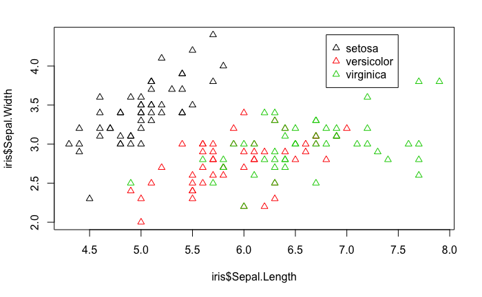

```r
plot(iris$Sepal.Length, iris$Sepal.Width, col = iris$Species, pch = 2)
legend(6.8, 4.4, unique(iris$Species), col = 1:length(iris$Species), pch = 2)
```

Adding some colour helps to see what is going on here. In short, you can do a lot with ‘base’ graphics.

## GGplot2

The ‘GG’ in `ggplot2` stands for ‘grammar of graphics’. The general idea is that there should be rules for hierarchically organizing information into a data visualization. This is actually quite complex and mostly beyond the scope of what we want to do today. The essential idea is that in a simple plot there are `x` and `y` coordinates and then additional information layers are added on (like the mapping of colour onto `iris$Species`, above). I will argue that this creates a simple, transparent, and powerful approach to creating visualizations. You can still end up with chunks of code like below to create a single plot, but the important thing is that it will (eventually - likely not today) be clear what the code is doing. And normally, you can get what you want with much less code.

```r
theme_tufteNL <- function (base_size = 20, base_family = "serif", ticks = TRUE)
{
    ret <- theme_bw(base_family = base_family, base_size = base_size) +
        theme(legend.position="right", legend.background = element_blank(), legend.key = element_blank(),
            panel.background = element_blank(), panel.border = element_blank(),
            strip.background = element_blank(), plot.background = element_blank(),
            axis.line = element_blank(), panel.grid = element_blank())
    if (!ticks) {
        ret <- ret + theme(axis.ticks = element_blank())
    }
    ret
}


AllSta <- ggplot(AllIA1GrandAvgS, aes(x = (IDX*20), y = mean, color = IA)) +
    geom_line() +
    geom_errorbar(aes(ymin = mean - se, ymax = mean + se), alpha = .4, width = 0.3) +
    geom_vline(xintercept = vlineStcueMeans, alpha = 0.5) +
    geom_vline(xintercept = vlineStcueSD, linetype = "longdash", alpha = 0.5) +
    scale_x_continuous(breaks = seq(0, 6000, 1000)) + scale_y_continuous(breaks = seq(0, .8, .2)) +
    labs(title = "Statements", y = NULL, x = "Time") +
    facet_grid(ModGroup ~.) +
    theme_tufteNL2()
```

[figure not shown]